# 4 Analysis

In this analysis we aim to show that QR can achieve similar— if not better— performance to OLS across various metrics. OLS and QR are very different modeling techniques, and, as such, it is difficult to compare them. However, given that OLS estimates the mean value of the response variable for a given input vector and QR estimates the nth quantile of the response variable for a given input vector, the 50th quantile QR (QR50)— which corresponds to the median— can be used as a comparison to OLS as both the median and mean are measures of centrality. The limitation of this analysis is that the data set does not meet the assumptions of OLS. Specifically, the data is heavily skewed and the conditional distributions are also skewed, meaning median of the conditional distribution is a better proxy for the centrality of the distribution. The power of QR is that it is able to produce similar results to OLS regression without having to meet the strict assumptions of OLS. Regardless of the fact the OLS regressions are statistically invalid, it is still going to minimizee the square deviations of the residuals from the regression curve, which often results much higher scores across popular metrics than other modeling techniques, and will thus serve as a proper benchmark to test the mettle of QR in a data set that is beyond the capabilities of OLS regression.

## 4.1 Visualization

### 4.1.1 Visualizing the Data

There are many different kinds of predictor variables in this data set. For instance, there are continuous variables such as GrLivArea, counting variables such as YearBuilt, and categorical variables such as HouseStyle. In all of these cases, we can see that the data is not normally distributed, including the response variable, SalePrice. The relationships between the variables and their distributions are illustrated in a joint plot below.

using (Auguie 2017) and (Wickham 2016)

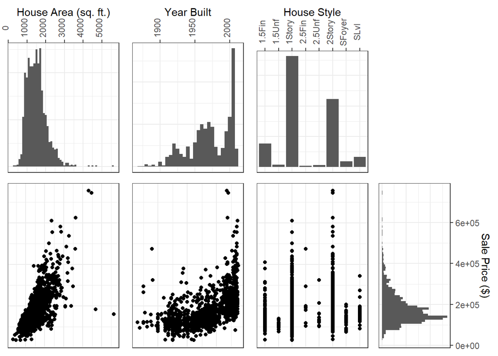

```r
suppressWarnings({

p1 <- df |> ggplot(aes(x = GrLivArea)) + geom_histogram(binwidth = 100) + theme_bw() + theme(axis.text.y = element_blank(), axis.text.x = element_text(angle = 90), axis.ticks.y = element_blank()) + ylab(NULL) + xlab("House Area (sq. ft.)") + scale_x_continuous(position = "top")

p2 <- df |> ggplot(aes(x = YearBuilt)) + geom_histogram(binwidth = 5) + theme_bw() + theme(axis.text.y = element_blank(), axis.text.x = element_text(angle = 90), axis.ticks.y = element_blank()) + ylab(NULL) + xlab("Year Built") + scale_x_continuous(position = "top")

p3 <- df |> ggplot(aes(x = HouseStyle)) + geom_histogram(stat="count") + theme_bw() + theme(axis.text.y = element_blank(), axis.text.x = element_text(angle = 90), axis.ticks.y = element_blank()) + ylab(NULL) + xlab("House Style") + scale_x_discrete(position = "top")

p4 <- ggplot() + theme_minimal()

p5 <- df |> ggplot(aes(x = GrLivArea, y = SalePrice)) + geom_point() + theme_bw() + theme(axis.text = element_blank(), axis.ticks = element_blank()) + ylab(NULL) + xlab(NULL)

p6 <- df |> ggplot(aes(x = YearBuilt, y = SalePrice)) + geom_point() + theme_bw() + theme(axis.text = element_blank(), axis.ticks = element_blank()) + ylab(NULL) + xlab(NULL)

p7 <- df |> ggplot(aes(x = HouseStyle, y = SalePrice)) + geom_point() + theme_bw() + theme(axis.text = element_blank(), axis.ticks = element_blank()) + ylab(NULL) + xlab(NULL)

p8 <- df |> ggplot(aes(x = SalePrice)) + geom_histogram(binwidth = 10000) + theme_bw() + ylab(NULL) + xlab("Sale Price ($)") + coord_flip() + scale_x_continuous(position = "top") + theme(axis.text.x = element_blank(), axis.ticks.x = element_blank())

grid.arrange(p1, p2, p3, p4, p5, p6, p7, p8, nrow = 2)

})
```

Thus, the data fails to meet the assumptions of OLS, requiring the usage of a more flexible model like QR.

### 4.1.2 Visualizing quantile regression vs OLS

#### 4.1.2.1 Difference between the 50th quantile and mean.

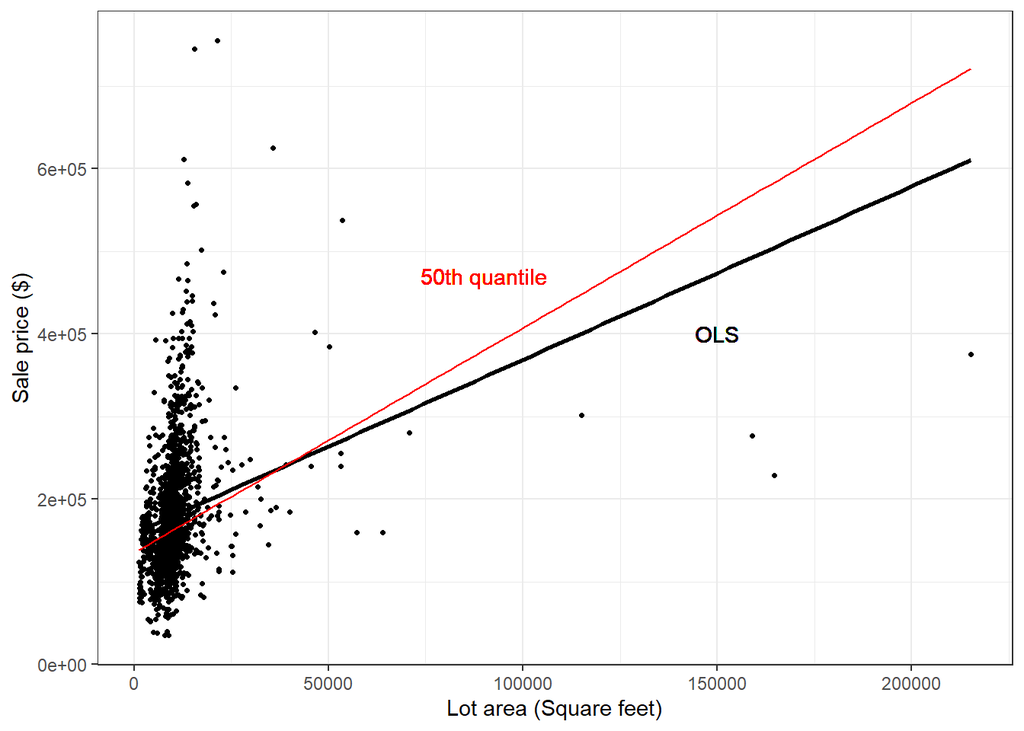

```r
df |> ggplot(aes(y = SalePrice, x = LotArea)) +
  geom_point(size = 0.9) +
  geom_smooth(method = lm, se = F, color = "black") +
  geom_text(aes(y = 400000, x = 150000, label = "OLS"), color="black") +
  geom_quantile(quantiles=0.5, color="red") +
  geom_text(aes(y = 470000, x = 90000, label = "50th quantile"), color="red") +
  ylab("Sale price ($)") +
  xlab("Lot area (Square feet)") +
  theme_bw()
```

in the previous graph, we can visualize one of the advantages of Quantile regression. The slope of OLS is slightly lower than the slope of 50th quantile. That is mostly due to the 3 points which look like outliers on the far right below the OLS slope. They heavily affect the value of the OLS but the Quantile regression is unaffected by it due to the mathematical property of the median.

#### 4.1.2.2 Viewing the different quantiles of Quantile regression.

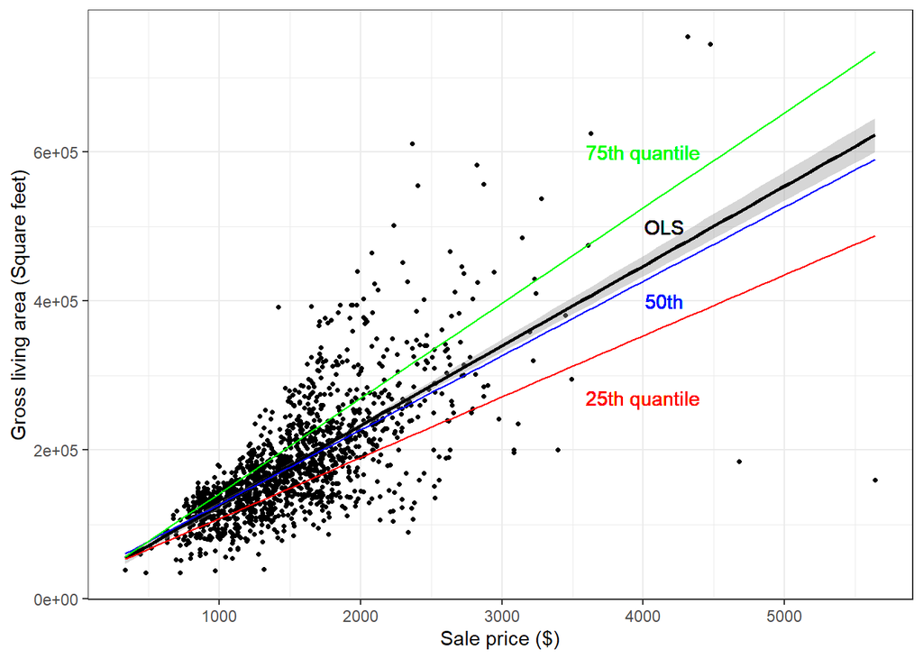

```r
df |> ggplot(aes(y = SalePrice, x = GrLivArea)) +
  geom_point(size = 0.9) +
  stat_smooth(method = lm, color = "black") +
  geom_text(aes(x = 4150, y = 500000, label = "OLS"), color="black") +
  geom_quantile(quantiles=0.25, color="red") +
  geom_text(aes(x = 4000, y = 270000, label = "25th quantile"), color="red") +
  geom_quantile(quantiles=0.5, color="blue") +
  geom_text(aes(x = 4150, y = 400000, label = "50th"), color="blue") +
  geom_quantile(quantiles=0.75, color="green") +
  geom_text(aes(x = 4000, y = 600000, label = "75th quantile"), color="green") +
  xlab("Sale price ($)") +
  ylab("Gross living area (Square feet)") +
  theme_bw()
```

In this graph, when plotting sales price against gross living area, Quantile regression 50th quantile and OLS look very similar in slope and y-intercept. However, when viewing the greater picture, Quantile regression actually offers a special regression line calculation for every partition of data as determined by tau value. So for the 75th quantile line, this slope would be the best to describe the prices for houses with gross living area around the 75% quantile of house prices. While the 25th quantile line would be the best at describing houses around gross living areas around the 25th quantile of house prices.

## 4.2 Model creation

### 4.2.1 QR model

quantile regression models using (Koenker 2023)

```r
ols_grlivarea = lm(data=df, SalePrice ~ GrLivArea)
print(ols_grlivarea$coefficients)
```

```
(Intercept)   GrLivArea
 18569.0259    107.1304
```

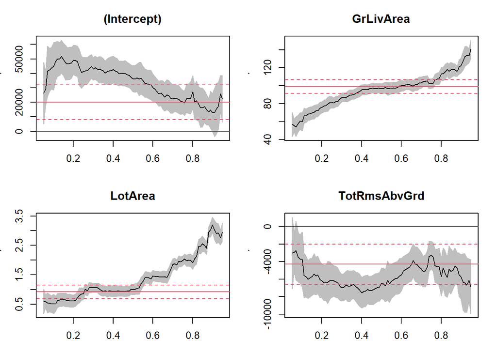

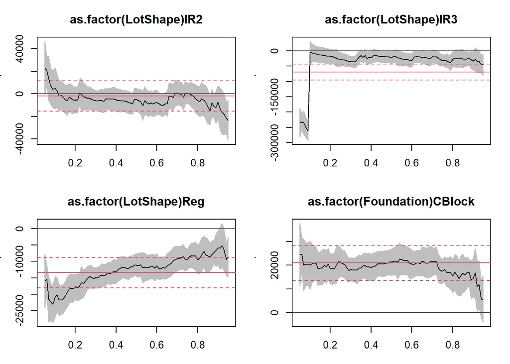

```r
num_of_rows <- nrow(qrs$coefficients)
#par(mfrow = c(2, 2))
#plot.new()
#mtext("Beta change per quantile level", side = 3, line = - 2, outer = TRUE)
#plot(ols)
plot(summary(qrs, se="iid"), xlab="Quantiles", ylab="Y-Intercepts", type="l", mfrow = c(2,2))
```

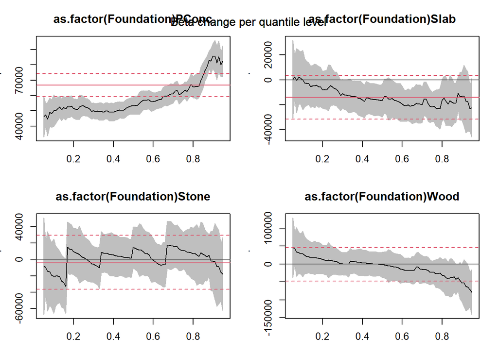

```r
#abline(h=ols_grlivarea$coefficients[2], col="blue", type="l")
#plot(qrs$coefficients[2, ], xlab="Quantiles", ylab="Lot-Area", type="l")
#plot(qrs$coefficients[3, ], xlab="Quantiles", ylab="TotRmsAbvGrd", type="l")
#plot(qrs$coefficients[4, ], xlab="Quantiles", ylab="LotShape-IR2", type="l")
mtext("Beta change per quantile level", side = 3, line = - 2, outer = TRUE)
#plot(qrs$coefficients[5, ], xlab="Quantiles", ylab="LotShape-IR3", type="l")
#plot(qrs$coefficients[6, ], xlab="Quantiles", ylab="LotShape-Reg", type="l")
#plot(qrs$coefficients[7, ], xlab="Quantiles", ylab="Foundation-CBlock", type="l")
#plot(qrs$coefficients[8, ], xlab="Quantiles", ylab="Foundation-PConc", type="l")
mtext("Beta change per quantile level", side = 3, line = - 2, outer = TRUE)
```

```r
#plot(qrs$coefficients[9, ], xlab="Quantiles", ylab="Foundation-Slab", type="l")
#plot(qrs$coefficients[10, ], xlab="Quantiles", ylab="Foundation-Stone", type="l")
#plot(qrs$coefficients[11, ], xlab="Quantiles", ylab="Foundation-Wood", type="l")
```

## 4.3 Interpretation of betas

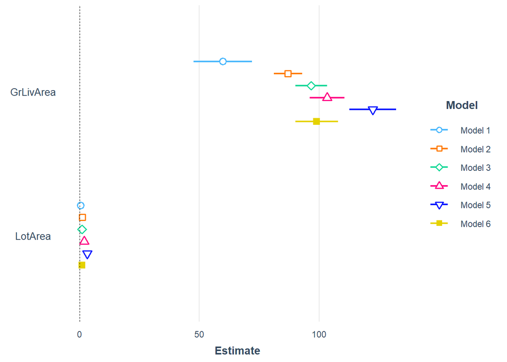

```r
options(scipen=5)
ols = lm(data=df, SalePrice ~ GrLivArea + LotArea + TotRmsAbvGrd + as.factor(LotShape) + as.factor(Foundation))
qr10 = rq(data=df, SalePrice ~ GrLivArea + LotArea + TotRmsAbvGrd + as.factor(LotShape) + as.factor(Foundation), tau=.1)
qr30 = rq(data=df, SalePrice ~ GrLivArea + LotArea + TotRmsAbvGrd + as.factor(LotShape) + as.factor(Foundation), tau=.3)
qr50 = rq(data=df, SalePrice ~ GrLivArea + LotArea + TotRmsAbvGrd + as.factor(LotShape) + as.factor(Foundation), tau=.5)
qr70 = rq(data=df, SalePrice ~ GrLivArea + LotArea + TotRmsAbvGrd + as.factor(LotShape) + as.factor(Foundation), tau=.7)
qr90 = rq(data=df, SalePrice ~ GrLivArea + LotArea + TotRmsAbvGrd + as.factor(LotShape) + as.factor(Foundation), tau=.9)
plot_summs(qr10, qr30, qr50, qr70, qr90, ols, se="iid", ci=.95, omit.coefs = c("(Intercept)", "as.factor(LotShape)IR2", "as.factor(LotShape)IR3", "as.factor(LotShape)Reg", "as.factor(Foundation)CBlock", "as.factor(Foundation)PConc", "as.factor(Foundation)Slab", "as.factor(Foundation)Stone", "as.factor(Foundation)Wood", "TotRmsAbvGrd")) #, qr50, qr70, qr90)
```

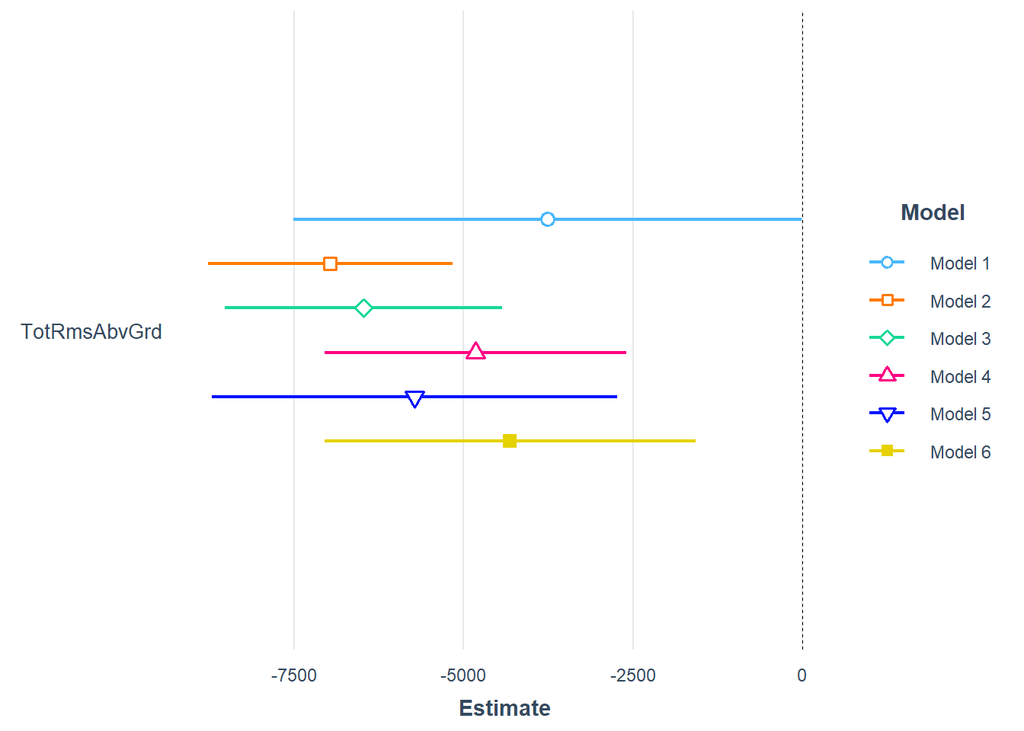

```r
plot_summs(qr10, qr30, qr50, qr70, qr90, ols, se="iid", ci=.95, omit.coefs = c("(Intercept)", "as.factor(LotShape)IR2", "as.factor(LotShape)IR3", "as.factor(LotShape)Reg", "as.factor(Foundation)CBlock", "as.factor(Foundation)PConc", "as.factor(Foundation)Slab", "as.factor(Foundation)Stone", "as.factor(Foundation)Wood", "GrLivArea", "LotArea")) #, qr50, qr70, qr90)
```

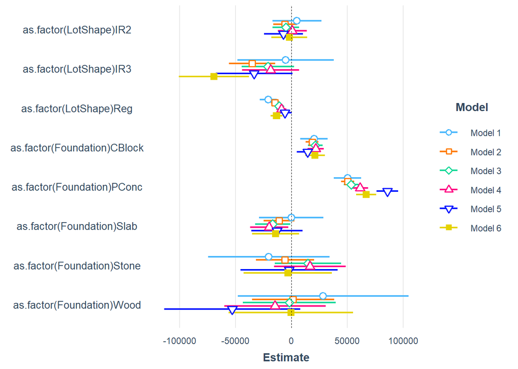

```r
plot_summs(qr10, qr30, qr50, qr70, qr90, ols, se="iid", ci=.95, omit.coefs = c("(Intercept)", "GrLivArea", "LotArea", "TotRmsAbvGrd"))
```

```r
export_summs(qr10, qr30, qr50, qr70, qr90, ols, se="iid")
```

|  | Model 1 | Model 2 | Model 3 | Model 4 | Model 5 | Model 6 |
| --- | --- | --- | --- | --- | --- | --- |
| (Intercept) | 44918.14 *** | 43104.15 *** | 36326.81 *** | 22388.39 *** | 12828.55 | 20050.09 ** |
|  | (9958.59) | (4786.61) | (5436.58) | (5905.57) | (7945.83) | (7266.77) |
| GrLivArea | 59.78 *** | 86.99 *** | 96.67 *** | 103.31 *** | 122.36 *** | 98.93 *** |
|  | (6.22) | (2.99) | (3.39) | (3.69) | (4.96) | (4.54) |
| LotArea | 0.51 ** | 1.06 *** | 1.00 *** | 1.85 *** | 3.20 *** | 0.92 *** |
|  | (0.20) | (0.09) | (0.11) | (0.12) | (0.16) | (0.14) |
| TotRmsAbvGrd | -3760.05 * | -6971.12 *** | -6476.18 *** | -4824.76 *** | -5722.68 *** | -4312.74 ** |
|  | (1913.59) | (919.77) | (1044.67) | (1134.78) | (1526.83) | (1396.35) |
| as.factor(LotShape)IR2 | 4840.55 | -5886.44 | -5084.13 | 643.09 | -7348.43 | -2008.94 |
|  | (11118.13) | (5343.95) | (6069.59) | (6593.19) | (8871.02) | (8112.89) |
| as.factor(LotShape)IR3 | -5205.53 | -35251.72 *** | -21074.81 | -18689.73 | -33498.32 | -69356.24 *** |
|  | (21961.72) | (10555.93) | (11989.30) | (13023.57) | (17522.97) | (16025.44) |
| as.factor(LotShape)Reg | -20808.19 *** | -14850.39 *** | -11065.07 *** | -9142.87 *** | -5890.43 | -13415.52 *** |
|  | (3849.01) | (1850.03) | (2101.24) | (2282.51) | (3071.08) | (2808.62) |
| as.factor(Foundation)CBlock | 20043.99 ** | 18347.28 *** | 21252.41 *** | 21512.77 *** | 14295.61 ** | 20940.32 *** |
|  | (6163.21) | (2962.36) | (3364.61) | (3654.86) | (4917.55) | (4497.29) |
| as.factor(Foundation)PConc | 50167.36 *** | 50155.98 *** | 53311.16 *** | 61323.28 *** | 85822.78 *** | 66791.95 *** |
|  | (6223.23) | (2991.20) | (3397.38) | (3690.45) | (4965.44) | (4541.08) |
| as.factor(Foundation)Slab | -264.83 | -11272.18 | -16867.21 * | -20032.89 * | -13083.83 | -14262.10 |
|  | (14627.68) | (7030.81) | (7985.52) | (8674.39) | (11671.23) | (10673.80) |
| as.factor(Foundation)Stone | -20399.97 | -5889.52 | 14561.55 | 16429.67 | -2166.19 | -3395.83 |
|  | (27696.30) | (13312.26) | (15119.92) | (16424.25) | (22098.52) | (20209.95) |
| as.factor(Foundation)Wood | 28298.39 | 1356.26 | -2008.82 | -14804.37 | -53100.42 | -555.32 |
|  | (38945.74) | (18719.32) | (21261.19) | (23095.30) | (31074.31) | (28418.66) |
| N | 1460 | 1460 | 1460 | 1460 | 1460 | 1460 |
| tau | 0.10 | 0.30 | 0.50 | 0.70 | 0.90 |  |
| R1 | 0.29 | 0.38 | 0.44 | 0.48 | 0.54 |  |
| AIC | 35721.34 | 35194.94 | 35180.97 | 35468.82 | 36275.49 | 35656.56 |
| BIC | 35784.78 | 35258.37 | 35244.41 | 35532.26 | 36338.92 | 35725.28 |
| R2 |  |  |  |  |  | 0.63 |
| *** p < 0.001; ** p < 0.01; * p < 0.05. |  |  |  |  |  |  |

### 4.3.1 OLS model

```r
ols = lm(data=df, SalePrice ~ GrLivArea + LotArea + TotRmsAbvGrd + as.factor(LotShape) + as.factor(Foundation))
ols_summary = summary(ols)
```

## 4.4 Model evaluation

### 4.4.1 Mean absolute error

calculations using (Hamner and Frasco 2018)

```r
# function to make text underlined
emphSmaller <- function(s, c) {
  ifelse(abs(as.numeric(s)) <= abs(as.numeric(c)), paste("<u>", s, "</u>", sep=""), paste(s, sep=""))
}

##########################################################
# Whole data predictions
##########################################################
olsMae = mae(predict(ols), df$SalePrice)
Qr50Mae = mae(predict(qr50), df$SalePrice)

##########################################################
# creating data for house prices greater than 90% of others.
##########################################################
fullDataLength = length(df$SalePrice)
count10per = fullDataLength / 10
sorted_df_desc <- df[order(-df$SalePrice),]
Q90SalePrice <- sorted_df_desc[0:count10per, ]

##########################################################
# 90th quantile predictions
##########################################################
qr90_m = rq(data=df, SalePrice ~ GrLivArea + LotArea + TotRmsAbvGrd + as.factor(LotShape) + as.factor(Foundation), tau=0.90)

ols_q90_predictions <- predict(ols, newdata=Q90SalePrice)
ols_q90_mae <- mae(ols_q90_predictions, Q90SalePrice$SalePrice)

qr90_q90_predictions <- predict(qr90_m, newdata=Q90SalePrice)
qr90_q90_mae <- mae(qr90_q90_predictions, Q90SalePrice$SalePrice)

##########################################################
# creating data for house prices lower than 90% of others.
##########################################################
sorted_df_asc <- df[order(df$SalePrice),]
Q10SalePrice <- sorted_df_asc[0:count10per, ]

##########################################################
# 10th quantile predictions
##########################################################
qr10_m = rq(data=df, SalePrice ~ GrLivArea + LotArea + TotRmsAbvGrd + as.factor(LotShape) + as.factor(Foundation), tau=0.10)

ols_q10_predictions <- predict(ols, newdata=Q10SalePrice)
ols_q10_mae <- mae(ols_q10_predictions, Q10SalePrice$SalePrice)

qr10_q10_predictions <- predict(qr10_m, newdata=Q10SalePrice)
qr10_q10_mae <- mae(qr10_q10_predictions, Q10SalePrice$SalePrice)
```

For *All* houses

| Model | Data | MAE |
| --- | --- | --- |
| OLS: | All | 32186.89 |
| QR-tau=0.5: | All | 31160.69 |

For houses *above* 90% of others

| Model | Data | MAE |
| --- | --- | --- |
| OLS: | 90th-Quantile | 82879.02 |
| QR-tau=0.9: | 90th-Quantile | 55993.4 |

For houses *below* 90% of others

| Model | Data | MAE |
| --- | --- | --- |
| OLS: | 10th-Quantile | 30663.33 |
| QR-tau=0.1: | 10th-Quantile | 19342.85 |

**Note**: underlined Quantile regression values are smaller (better).

When predicting the whole dataset, OLS MAE: 32186.89, and QR 50th MAE: 31160.69 are almost the same, with a slight improvement with quantile regression.

However when comparing Quantile regression (QR) for tau = 0.90 with OLS while predicting the top 10% priced houses when sorted by sales amount, and also when comparing QR with tau = 0.1 when prediction the lowest 10% priced houses, we can see that QR has much more accurate (lower error value) predictions because it is using a specialized model for the specific quantile of data it is predicting.

### 4.4.2 Root mean squared error

calculations using (Hamner and Frasco 2018)

```r
# OLS RMSE when predicting all the quantiles
olsRmse = rmse(predict(ols), df$SalePrice)

# QR-tau=0.5 RMSE when predicting all the quantiles
Qr50Rmse = rmse(predict(qr50), df$SalePrice)

# OLS RMSE when predicting the top 10% priced houses
ols_q90_rmse <- rmse(ols_q90_predictions, Q90SalePrice$SalePrice)

# QR-tau=0.9 RMSE when predicting the top 10% priced houses
qr90_q90_rmse <- rmse(qr90_q90_predictions, Q90SalePrice$SalePrice)

# OLS RMSE when predicting the bottom 10% priced houses
ols_q10_rmse <- rmse(ols_q10_predictions, Q10SalePrice$SalePrice)

# QR-tau=0.1 RMSE when predicting the bottom 10% priced houses
qr10_q10_rmse <- rmse(qr10_q10_predictions, Q10SalePrice$SalePrice)
```

For *All* houses

| Model | Data | RMSE |
| --- | --- | --- |
| OLS: | All | 48209.34 |
| QR-tau=0.5: | All | 49434.81 |

For houses *above* 90% of others

| Model | Data | RMSE |
| --- | --- | --- |
| OLS: | 90th-Quantile | 103618.1 |
| QR-tau=0.9: | 90th-Quantile | 82789.4 |

For houses *below* 90% of others

| Model | Data | RMSE |
| --- | --- | --- |
| OLS: | 10th-Quantile | 42084.84 |
| QR-tau=0.1: | 10th-Quantile | 24207.71 |

**Note**: underlined Quantile regression values are smaller (better).

Similarly, when calculating the RMSE value, OLS RMSE: 48209.34 and QR with tau = 0.5 RMSE: 49434.81 has very similar values even with OLS being slightly more accurate.

And when comparing Quantile regression (QR) for tau = 0.9 and 0.1 with OLS for the top and lowest 10% priced houses respectively, we can again see that QR has much more accurate predictions when judging by RMSE even though OLS is supposed to mininize the RMSE value.

### 4.4.3 Variance of error

```r
##########################################################
# Calculating residuals/errors
##########################################################
# ols residuals for all quantiles predictions
ols_r <- ols_summary$residuals
# QR-tau=0.5 residuals for all quantiles predictions
qr50_r <- qr50_summary$residuals
# ols residuals for 90th quantile predictions
ols_q90_r <- (ols_q90_predictions - Q90SalePrice$SalePrice) * -1
# QR-tau=0.9 residuals for 90th quantile predictions
qr90_q90_r <- (qr90_q90_predictions - Q90SalePrice$SalePrice) * -1
# ols residuals for 10th quantile predictions
ols_q10_r <- (ols_q10_predictions - Q10SalePrice$SalePrice) * -1
# QR-tau=0.1 residuals for 10th quantile predictions
qr10_q10_r <- (qr10_q10_predictions - Q10SalePrice$SalePrice) * -1

ols_var <- ols_summary$df[2]
qr_var <- qr50_summary$rdf
```

### 4.4.4 Min/max error

```r
##########################################################
# When predicting the whole data
##########################################################

# Min OLS error
ols_r_min <- format(round(min(ols_r), digits=0), scientific=F)
# Absolute min OLS error
ols_r_min_abs <- format(round(min(abs(ols_r)), digits=0), scientific=F)
# Max OLS error
ols_r_max <- format(round(max(ols_r), digits=0), scientific=F)
# Absolute max OLS error
ols_r_max_abs <- format(round(max(abs(ols_r)), digits=0), scientific=F)
# Avg QR OLS error
ols_r_mean_abs <- format(round(mean(abs(ols_r)), digits=0), scientific=F)

# Min QR 50th error
qr50_r_min <- format(round(min(qr50_r), digits=0), scientific=F)
# Absolute min QR 50th error
qr50_r_min_abs <- format(round(min(abs(qr50_r)), digits=0), scientific=F)
# Max QR 50th error
qr50_r_max <- format(round(max(qr50_r), digits=0), scientific=F)
# Absolute max QR 50th error
qr50_r_max_abs <- format(round(max(abs(qr50_r)), digits=0), scientific=F)
# Avg QR 50th error
qr50_r_mean_abs <- format(round(mean(abs(qr50_r)), digits=0), scientific=F)

##########################################################
# When predicting the top 10% of data (90th quantile)
##########################################################

# Avg OLS error
ols_q90_r_abs_avg <- format(round(mean(abs(ols_q90_r)), digits=0), scientific=F)
# Min OLS error
ols_q90_r_min <- format(round(min(ols_q90_r), digits=0), scientific=F)
# Absolute min OLS error
ols_q90_r_min_abs <- format(round(min(abs(ols_q90_r)), digits=0), scientific=F)
# Max OLS error
ols_q90_r_max <- format(round(max(ols_q90_r), digits=0), scientific=F)
# Absolute max OLS error
ols_q90_r_max_abs <- format(round(max(abs(ols_q90_r)), digits=0), scientific=F)

# Avg QR 90th error
qr90_q90_r_abs_avg <- format(round(mean(abs(qr90_q90_r)), digits=0), scientific=F)
# Min QR 90th error
qr90_q90_r_min <- format(round(min(qr90_q90_r), digits=0), scientific=F)
# Absolute min QR 90th error
qr90_q90_r_min_abs <- format(round(min(abs(qr90_q90_r)), digits=0), scientific=F)
# Max QR 90th error
qr90_q90_r_max <- format(round(max(qr90_q90_r), digits=0), scientific=F)
# Absolute max QR 90th error
qr90_q90_r_max_abs <- format(round(max(abs(qr90_q90_r)), digits=0), scientific=F)

##########################################################
# When predicting the lowest 10% of data (10th quantile)
##########################################################

# Avg OLS error
ols_q10_r_abs_avg <- format(round(mean(abs(ols_q10_r)), digits=0), scientific=F)
# Min OLS error
ols_q10_r_min <- format(round(min(ols_q10_r), digits=0), scientific=F)
# Absolute min OLS error
ols_q10_r_min_abs <- format(round(min(abs(ols_q10_r)), digits=0), scientific=F)
# Max OLS error
ols_q10_r_max <- format(round(max(ols_q10_r), digits=0), scientific=F)
# Absolute max OLS error
ols_q10_r_max_abs <- format(round(max(abs(ols_q10_r)), digits=0), scientific=F)

# Avg QR 10th error
qr10_q10_r_abs_avg <- format(round(mean(abs(qr10_q10_r)), digits=0), scientific=F)
# Min QR 10th error
qr10_q10_r_min <- format(round(min(qr10_q10_r), digits=0), scientific=F)
# Absolute min QR 10th error
qr10_q10_r_min_abs <- format(round(min(abs(qr10_q10_r)), digits=0), scientific=F)
# Max QR 10th error
qr10_q10_r_max <- format(round(max(qr10_q10_r), digits=0), scientific=F)
# Absolute max QR 10th error
qr10_q10_r_max_abs <- format(round(max(abs(qr10_q10_r)), digits=0), scientific=F)
```

When predicting the *whole* data

| Model | Data | Mean | Min | Abs Min | Max | Abs Max |
| --- | --- | --- | --- | --- | --- | --- |
| OLS | All | 32187 | -422488 | 5 | 326538 | 422488 |
| QR-tau=0.5 | All | 31161 | -440106 | 0 | 351819 | 440106 |

When predicting *focused* data

| Model | Data | Mean | Min | Abs Min | Max | Abs Max |
| --- | --- | --- | --- | --- | --- | --- |
| OLS | 10th Quantile | 30663 | -138925 | 576 | 59177 | 138925 |
| QR-tau=0.1 | 10th Quantile | 19343 | -58839 | 0 | 53225 | 58839 |
| OLS | 90th Quantile | 82879 | -43529 | 1484 | 326538 | 326538 |
| QR-tau=0.9 | 90th Quantile | 55993 | -511780 | 0 | 245302 | 511780 |

**Note**: underlined Quantile regression values are smaller (better).

In the first table for predictions for the whole data, we can see that OLS and quantile regression have similar error metrics, with OLS having better min max values but that is because it cares a lot more to outliers therefore making these metrics better.

## 4.5 Tests for significant variables

We used a common function to help in calculating p-values

```r
getQrModel <- function(data1, tau1, equation) {
  rq(data=data1, equation, tau=tau1)
}

getPvalue <- function(model1, model2) {
  anova(model1, model2)["table"]$table$`pvalue`
}
```

### 4.5.1 Calculations:

```r
eq_full <- SalePrice ~ GrLivArea + LotArea + TotRmsAbvGrd + as.factor(LotShape) + as.factor(Foundation)
eq_no_foundation <- SalePrice ~ GrLivArea + LotArea + TotRmsAbvGrd + as.factor(LotShape)
eq_no_lotshape <- SalePrice ~ GrLivArea + LotArea + TotRmsAbvGrd + as.factor(Foundation)


qr15 <- getQrModel(df, 0.15, eq_full)
qr15_no_f <- getQrModel(df, 0.15, eq_no_foundation)
qr15_no_lot <- getQrModel(df, 0.15, eq_no_lotshape)

foundation_15_p <- getPvalue(qr15, qr15_no_f)
lotshape_15_p <- getPvalue(qr15, qr15_no_lot)


qr25 <- getQrModel(df, 0.25, eq_full)
qr25_no_f <- getQrModel(df, 0.25, eq_no_foundation)
qr25_no_lot <- getQrModel(df, 0.25, eq_no_lotshape)

foundation_25_p <- getPvalue(qr25, qr25_no_f)
lotshape_25_p <- getPvalue(qr25, qr25_no_lot)


qr50 <- getQrModel(df, 0.50, eq_full)
qr50_no_f <- getQrModel(df, 0.50, eq_no_foundation)
qr50_no_lot <- getQrModel(df, 0.50, eq_no_lotshape)

foundation_50_p <- getPvalue(qr50, qr50_no_f)
lotshape_50_p <- getPvalue(qr50, qr50_no_lot)


qr80 <- getQrModel(df, 0.80, eq_full)
qr80_no_f <- getQrModel(df, 0.80, eq_no_foundation)
qr80_no_lot <- getQrModel(df, 0.80, eq_no_lotshape)

foundation_80_p <- getPvalue(qr80, qr80_no_f)
lotshape_80_p <- getPvalue(qr80, qr80_no_lot)


qr95 <- getQrModel(df, 0.95, eq_full)
qr95_no_f <- getQrModel(df, 0.95, eq_no_foundation)
qr95_no_lot <- getQrModel(df, 0.95, eq_no_lotshape)

foundation_95_p <- getPvalue(qr95, qr95_no_f)
lotshape_95_p <- getPvalue(qr95, qr95_no_lot)
## q75, q10 and q90 gives singularity errors

anova_ols_foundation <- anova(ols, lm(data=df, eq_no_foundation))
anova_ols_lotshape <- anova(ols, lm(data=df, eq_no_lotshape))
```

Alpha=0.01

| Quantile | foundation p-value | significant? | lot shape p-value | significant? |
| --- | --- | --- | --- | --- |
| QR-tau=0.15 | 0 | TRUE | 5.7287508^{-14} | TRUE |
| QR-tau=0.25 | 0 | TRUE | 0 | TRUE |
| QR-tau=0.50 | 0 | TRUE | 0.0000002 | TRUE |
| QR-tau=0.80 | 0 | TRUE | 0.0036757 | TRUE |
| QR-tau=0.95 | 1.0735857^{-13} | TRUE | 0.2224687 | FALSE |
| OLS | 1.9786551^{-71} | TRUE | 0 | TRUE |

```r
qrs_summary <- summary(qrs, se = "iid")
#tau: 0.1
q10_sig <- qrs_summary[11][[1]]$coefficients[,4][0:4]
#tau: 0.25
q25_sig <- qrs_summary[26][[1]]$coefficients[,4][0:4]
#tau: 0.5
q50_sig <- qrs_summary[51][[1]]$coefficients[,4][0:4]
#tau: 0.75
q75_sig <- qrs_summary[76][[1]]$coefficients[,4][0:4]
#tau: 0.9
q90_sig <- qrs_summary[91][[1]]$coefficients[,4][0:4]
#ols significance
ols_pvalues <- ols_summary$coefficients[,4]
```

[output not shown]

## 4.6 Summary

To put our results into real world perspective, we have to take a step back and look at the bigger picture. In our example people normally when buying a house won’t be looking across all the house price range, but they would probably only focus on a specific range of house prices, whether it be expensive, cheap, or moderate. So, this is when quantile regression shines as it is a lot better than regular mean dependent models like OLS in predicting a specialized/focused dataset that doesn’t represent the whole population distribution. One more thing is that as demonstrated in our study, real world datasets are not normalized, and are not free from outliers, therefore when using OLS, it will suffer a lot from handling these types of data while quantile regression should be able to handle it in a much better way, providing more accurate results.

Auguie, Baptiste. 2017. *gridExtra: Miscellaneous Functions for "Grid" Graphics*. https://CRAN.R-project.org/package=gridExtra.

Hamner, Ben, and Michael Frasco. 2018. *Metrics: Evaluation Metrics for Machine Learning*. https://CRAN.R-project.org/package=Metrics.

Koenker, Roger. 2023. *Quantreg: Quantile Regression*. https://CRAN.R-project.org/package=quantreg.

Wickham, Hadley. 2016. *Ggplot2: Elegant Graphics for Data Analysis*. Springer-Verlag New York. https://ggplot2.tidyverse.org.